# ML test

# Visualising the data

## Auxiliary function & Chord Plot params

```r
# adjust parameters:

circos.clear() # reset params

circos.par( # set a bunch of stuff
  start.degree = 90,
  gap.degree = 4,
  track.margin = c(-0.1, 0.1),
  points.overflow.warning = FALSE
)

# set plot parameters:
par(mar = # margins
      rep(0,4)) # 0 repeated 4 times

# create an auxiliary function
chord_plot <- function(my_data) {

  chordDiagram(
    x = my_data,
    transparency = 0.25,
    directional = 1,
    direction.type = c("arrows", "diffHeight"),
    diffHeight  = -0.04,
    annotationTrack = "grid",
    annotationTrackHeight = c(0.05, 0.1),
    link.arr.type = "big.arrow",
    link.sort = TRUE,
    link.largest.ontop = TRUE)

  # text and axis
  circos.trackPlotRegion(
    track.index = 1,
    bg.border = NA,
    panel.fun = function(x, y) {

      xlim = get.cell.meta.data("xlim")
      sector.index = get.cell.meta.data("sector.index")

      # Add names to the sector
      circos.text(
        x = mean(xlim),
        y = 3.2,
        labels = sector.index,
        facing = "bending",
        cex = 0.8
        )
    }
  )
}
```

## Chord Plot

```
* NA -> ...3
```

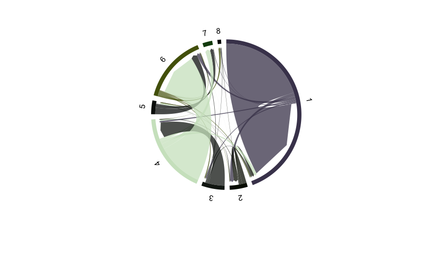

```r
freq_table %>%
  transmute(
    start_nh = as.integer(start_nh),
    end_nh = as.integer(end_nh),
  ) %>%
  bind_cols(freq_table$n) %>%
  chord_plot()
```

# Statistical Learning - Classification and Regression

Let’s wrap up and start building a ML model. We split the data in two to make a classification and a regression problem.

```r
df <- trips %>%
  # reduce the number of levels in the factor features
  mutate(
    # select those with p > 10e-02
    StartNH = fct_lump(StartNH, 5),
    EndNH = fct_lump(EndNH, 5)
  )

nh_trips <- df %>%
  # select only features related to neighbourhoods
  select(TripID, # only as identifier
         Duration, Distance, EndTime,# wont'be used: contain info about the end point
         StartTime, # will be split into dummies
         StartNH,
         EndNH, # target
         ShortTrip, Covid # other dummies
  )

lonlat_trips <- df %>%
  # select only features related to coordinates (lon-lat)
  select(TripID,
         Duration, Distance, EndTime,
         StartTime,
         StartLatitude, StartLongitude,
         EndLatitude, EndLongitude,
         ShortTrip, Covid)
```

It is very likely that we will not use `EndTime`, `Duration` and `Distance` as they already contain information about the end point!

# Split in Train and Test Data

As we noticed above, there is a real class imbalance.

```r
nh_trips %>%
  count(StartNH) %>%
  mutate(prop = n/sum(n)) %>%
  arrange(desc(prop))
```

| StartNH | n | prop |
| --- | --- | --- |
| Downtown | 185295 | 0.49273640 |
| University | 107366 | 0.28550763 |
| Southeast Core | 36409 | 0.09681880 |
| West Core | 19839 | 0.05275586 |
| Northeast Core | 14864 | 0.03952634 |
| Other | 12280 | 0.03265497 |

```r
nh_trips %>%
  count(EndNH) %>%
  mutate(prop = n/sum(n)) %>%
  arrange(desc(prop))
```

| EndNH | n | prop |
| --- | --- | --- |
| Downtown | 180207 | 0.47920639 |
| University | 108322 | 0.28804982 |
| Southeast Core | 37131 | 0.09873874 |
| West Core | 17462 | 0.04643494 |
| Northeast Core | 17095 | 0.04545902 |
| Other | 15836 | 0.04211109 |

```r
set.seed(42)

nh_split <- initial_split(nh_trips, strata = EndNH)

nh_train <- training(nh_split)
nh_test <- testing(nh_split)
```

Let’s check proportions:

```r
nh_train %>%
  count(EndNH) %>%
  mutate(prop = n/sum(n)) %>%
  arrange(desc(prop))
```

| EndNH | n | prop |
| --- | --- | --- |
| Downtown | 135170 | 0.47925826 |
| University | 81296 | 0.28824280 |
| Southeast Core | 27887 | 0.09887605 |
| West Core | 13029 | 0.04619558 |
| Northeast Core | 12805 | 0.04540136 |
| Other | 11853 | 0.04202595 |

```r
nh_test %>%
  count(EndNH) %>%
  mutate(prop = n/sum(n)) %>%
  arrange(desc(prop))
```

| EndNH | n | prop |
| --- | --- | --- |
| Downtown | 45037 | 0.47905077 |
| University | 27026 | 0.28747088 |
| Southeast Core | 9244 | 0.09832683 |
| West Core | 4433 | 0.04715305 |
| Northeast Core | 4290 | 0.04563199 |
| Other | 3983 | 0.04236648 |

# Define a recipe

Let’s define a recipe to address this problem. We shall `downsample` the data, which would achieve two goals:

1. Address class imbalance.
2. Reduce computational workload, given our limited resources.

```r
nh_recipe <- nh_train %>%
  recipe(EndNH ~ .) %>%
  # define identifier variable
  update_role(TripID, new_role =  'id') %>%
  # quantities only know at the end of the trip
  update_role(EndTime, Duration, Distance = 'ex-post') %>%
  # problem: step_date does not extract times!
  step_mutate(HourNum = format(strptime(StartTime,'%Y-%m-%d %H:%M:%S'),'%H')) %>%
  # turn it into a factor
  step_string2factor(HourNum) %>%
  # create factors out of StartTime
  step_date(StartTime, features = c('dow', 'month', 'year')) %>%
  # remove StartTime col
  step_rm(StartTime) %>%
  # turn factor-features into binary dummies (i.e. one per column: 1-0):
  step_dummy(all_nominal(), -all_outcomes()) %>%
  # remove predictors with zero variance:
  step_zv(all_predictors()) %>%
  # downsample the data
  step_downsample(EndNH, under_ratio = 1)
```

```
Error: Can't subset columns that don't exist.
x Column `ex-post` doesn't exist.
Run `rlang::last_error()` to see where the error occurred.
```

Note: `step_mutate(...)`is the same as the following:

```
trips %>%
  mutate(
    HourNum = format(strptime(StartTime,'%Y-%m-%d %H:%M:%S'),'%H')
  )
```

In the last step, by setting `under_ratio = 1` we bring the number of samples of all majority classes equal to 100% of the minority class, in this case `other`. This seems reasonable, as `Downtown` is more than 10 times more frequent than `other`. Now we can start thinking of our models!